# REGRESIÓN LINEAL CON REGULARIZACIONES DE RIDGE Y LASSO

Enunciado

Se toma el dataset “Salaries.csv”. El conjunto de datos está formado por los salarios de nueve meses recogidos de 397 profesores universitarios en Estados Unidos durante 2008 y 2009. Además de los salarios, también se recogieron el rango del profesor, el sexo, la disciplina, los años desde el doctorado y los años de servicio.

```
  1. rank: Categórica - de profesor asistente, profesor asociado o catedrático
  2. discipline: Categórica - Tipo de departamento en el que trabaja el profesor, ya sea aplicado (B) o teórico (A)
  3. yrs.since.phd: Continuo - Número de años desde que el profesor obtuvo su doctorado
  4. yrs.service: Continuo - Número de años que el profesor ha prestado servicio al departamento y/o a la universidad
  5. sex: Categórico - Sexo del profesor, hombre o mujer
  6. salary: Continuo - Sueldo de nueve meses del profesor (USD)
```

El objetivo de esta práctica consiste en realizar un estudio íntegro del dataset para terminar implementando un modelo lineal regularizado que realice predicciones sobre el salario para percibir de un profesor. Asimismo, se pedirá aprovechar la explicabilidad de estos modelos y los estudios estadísticos realizados para arrojar intuiciones y dependencias en los datos.

NOTA: Este caso práctico debe realizarse íntegramente en R.

Se pide

1. Cargar los datos. Realizar una inspección por variables de la distribución de salarios en función de cada atributo visualmente. Realizar las observaciones pertinentes. ¿Qué variables son mejores para separar los datos?
2. ¿Se puede emplear un test paramétrico para determinar si las medias de salarios entre hombres y mujeres son las mismas o difieren? Hay que tener en cuenta que, en tanto que se pide usar un test paramétrico, se deberá determinar si las muestras cumplen con las hipótesis necesarias.
3. Dividir el dataset tomando las primeras 317 instancias como train y las últimas 80 como test. Entrenar un modelo de regresión lineal con regularización Ridge y Lasso en train seleccionando el que mejor MSE tenga. Dar las métricas en test. Valorar el uso del one hot encoder, y, en caso de emplearlo, argumentarlo.
4. Estudiar la normalidad de los residuos del modelo resultante. ¿Se detecta algún sesgo?
5. ¿Qué conclusiones se extraen de este estudio y del modelo implementado? ¿Es correcto el rendimiento de este?
1. Cargar los datos. Realizar una inspección por variables de la distribución de salarios en función de cada atributo visualmente. Realizar las observaciones pertinentes. ¿Qué variables son mejores para separar los datos?

Carga y vistazo de los datos:

```r
df <- read.csv("archivos\\Salaries.csv", header=TRUE, sep=',')
head(df, 20)
```

|  | X | rank | discipline | yrs.since.phd | yrs.service | sex | salary |
| --- | --- | --- | --- | --- | --- | --- | --- |
| 1 | 1 | Prof | B | 19 | 18 | Male | 139750 |
| 2 | 2 | Prof | B | 20 | 16 | Male | 173200 |
| 3 | 3 | AsstProf | B | 4 | 3 | Male | 79750 |
| 4 | 4 | Prof | B | 45 | 39 | Male | 115000 |
| 5 | 5 | Prof | B | 40 | 41 | Male | 141500 |
| 6 | 6 | AssocProf | B | 6 | 6 | Male | 97000 |
| 7 | 7 | Prof | B | 30 | 23 | Male | 175000 |
| 8 | 8 | Prof | B | 45 | 45 | Male | 147765 |
| 9 | 9 | Prof | B | 21 | 20 | Male | 119250 |
| 10 | 10 | Prof | B | 18 | 18 | Female | 129000 |

[output cut: 10 more lines]

```r
colnames(df)
```

```
[1] "X"             "rank"          "discipline"    "yrs.since.phd" "yrs.service"   "sex"           "salary"
```

```r
summary(df)
```

```
       X           rank            discipline        yrs.since.phd    yrs.service        sex                salary
 Min.   :  1   Length:397         Length:397         Min.   : 1.00   Min.   : 0.00   Length:397         Min.   : 57800
 1st Qu.:100   Class :character   Class :character   1st Qu.:12.00   1st Qu.: 7.00   Class :character   1st Qu.: 91000
 Median :199   Mode  :character   Mode  :character   Median :21.00   Median :16.00   Mode  :character   Median :107300
 Mean   :199                                         Mean   :22.31   Mean   :17.61                      Mean   :113706
 3rd Qu.:298                                         3rd Qu.:32.00   3rd Qu.:27.00                      3rd Qu.:134185
 Max.   :397                                         Max.   :56.00   Max.   :60.00                      Max.   :231545
```

Aunque no se especifica, se puede intuir que las variables “rank”, “discipline” y “sex” son factores, ya que todas toman valores de entre una serie finita cada una.

```r
factor_list <- list("rank", "discipline", "sex")

for (var_name in factor_list){
  df[[var_name]] <- factor(df[[var_name]])
}
```

```r
df
```

| X | rank | discipline | yrs.since.phd | yrs.service | sex | salary |
| --- | --- | --- | --- | --- | --- | --- |
| 1 | Prof | B | 19 | 18 | Male | 139750 |
| 2 | Prof | B | 20 | 16 | Male | 173200 |
| 3 | AsstProf | B | 4 | 3 | Male | 79750 |
| 4 | Prof | B | 45 | 39 | Male | 115000 |
| 5 | Prof | B | 40 | 41 | Male | 141500 |
| 6 | AssocProf | B | 6 | 6 | Male | 97000 |
| 7 | Prof | B | 30 | 23 | Male | 175000 |
| 8 | Prof | B | 45 | 45 | Male | 147765 |
| 9 | Prof | B | 21 | 20 | Male | 119250 |
| 10 | Prof | B | 18 | 18 | Female | 129000 |

[output cut: 387 more lines]

```r
summary(df)
```

```
       X              rank     discipline yrs.since.phd    yrs.service        sex          salary
 Min.   :  1   AssocProf: 64   A:181      Min.   : 1.00   Min.   : 0.00   Female: 39   Min.   : 57800
 1st Qu.:100   AsstProf : 67   B:216      1st Qu.:12.00   1st Qu.: 7.00   Male  :358   1st Qu.: 91000
 Median :199   Prof     :266              Median :21.00   Median :16.00                Median :107300
 Mean   :199                              Mean   :22.31   Mean   :17.61                Mean   :113706
 3rd Qu.:298                              3rd Qu.:32.00   3rd Qu.:27.00                3rd Qu.:134185
 Max.   :397                              Max.   :56.00   Max.   :60.00                Max.   :231545
```

Comprobación de nulos:

```r
sum(is.na(df))
```

```
[1] 0
```

No existen nulos.

Inspección gráfica por variables de la distribución de salarios en función de cada atributo y observaciones sobre las mismas:

- En primer lugar, se obviará la variable “X” por ser considerada una ID de cada observación, por lo que es irrelevante para la distribución de salarios.

```r
library(dplyr)

df <- df %>%
  select(-X)

df
```

| rank | discipline | yrs.since.phd | yrs.service | sex | salary |
| --- | --- | --- | --- | --- | --- |
| Prof | B | 19 | 18 | Male | 139750 |
| Prof | B | 20 | 16 | Male | 173200 |
| AsstProf | B | 4 | 3 | Male | 79750 |
| Prof | B | 45 | 39 | Male | 115000 |
| Prof | B | 40 | 41 | Male | 141500 |
| AssocProf | B | 6 | 6 | Male | 97000 |
| Prof | B | 30 | 23 | Male | 175000 |
| Prof | B | 45 | 45 | Male | 147765 |
| Prof | B | 21 | 20 | Male | 119250 |
| Prof | B | 18 | 18 | Female | 129000 |

[output cut: 387 more lines]

Algunas de las premisas previas que habrá que comprobar si se cumplen o no son:

- El “rank” debería influir en el salario, pues los profesores titulares deben cobrar más que los profesores asistentes y los asociados.
- Se desconoce si la oferta y demanda de profesores para la disciplina teórica es mayor o menor que para la disciplina aplicada, aunque es de esperar que, según la ley de Oferta y demanda, aquella disciplina que cuente con una mayor oferta de posibles candidatos ofrezca un menor salario - a mayor oferta, menor precio, en esta caso salario. No se espera, en todo caso, que su influencia en el salario sea tan alta como el “rank”.
- Los años desde que obtuvieron su titulación de doctorado (“yrs.since.phd”) debería ser una variable que influya poco, al menos no tanto como la variable años de servicio (“yrs.service”), la cual debería tener una influencia fuerte en el salario (es muy común en muchos países que el salario aumente a mayor número de años en la organización).
- El sexo por sí mismo no debería influir directamente en el salario, aunque es posible que lo haga debido a la influencia de otras variables (por ejemplo, si de media los hombres llevan más años en la universidad o si son más profesores y las mujeres más profesores asistentes, por ejemplo).

```r
library(ggplot2)
```

Análisis gráfico de la distribución del salario:

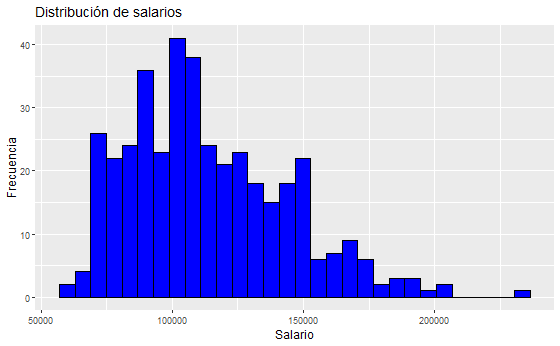

```r
ggplot(df, aes(salary)) +
  geom_histogram(bins = 30, fill = "blue", color = "black") +
  labs(title = "Distribución de salarios", x = "Salario", y = "Frecuencia")
```

De la distribución del salario se puede observar que tienen una gran acumulación en torno a 100.000$ con un descenso lento hacia salarios más altos y uno muy brusco hacia salarios más bajos. También se observa que existen algunos outliers, valores muy por encima de los 200.000$ que escapan a los puntos más normales.

```r
count(filter(df, salary > 200000))
```

| n |
| --- |
| 3 |

Se decide no eliminar estos valores outliers para no desvirtuar el resto de gráficas y que cuenten con el mismo número de observaciones, pero sería interesante considerar su eliminación o tratamiento de algún otro modo si esta EDA fuese a ser empleado en estudios posteriores.

Análisis gráfico rank - salary:

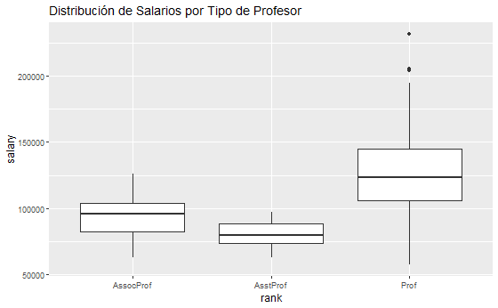

```r
ggplot(df, aes(rank, salary)) +
  geom_boxplot() +
  ggtitle("Distribución de Salarios por Tipo de Profesor")
```

A simple vista, se ve claramente que los Profesores cobran bastante más que los Profesores Asociados y muchísimo más que los Profesores Asistentes. De hecho, su mediana está muy por encima del valor máximo de estos últimos y prácticamente al mismo nivel que el máximo de los Profesores Asociados. También se observa que en los Profesores Asociados y Asistentes no existen valores outliers, pero sí existen varios en el caso de los Profesores, aunque no son muchos.

Análisis discipline - salary:

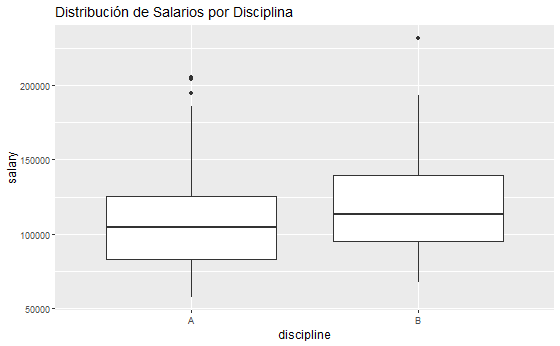

```r
ggplot(df, aes(discipline, salary)) +
  geom_boxplot() +
  ggtitle("Distribución de Salarios por Disciplina")
```

La diferencia de salario entre disciplinas no es muy elevada, aunque existe: los profesores de la disciplina B cobran un poco más que los de la disciplina A. Aunque todos los cuartiles de B están por encima de los de A, no existe una diferencia muy grande entre ellos. Se puede apreciar cómo también aquí existen valores considerados outliers en ambas disciplinas, aunque resulta llamativo que esta vez, para la disciplina A existe un valor extremo por debajo de 200.000$, mientras en la gráfica anterior todos los outliers estaban por encima de esta cifra. Es por este motivo que se tomó la decisión de no eliminar outliers en toda la duración del análisis gráfico, puesto que lo que es un valor extremo para una relación puede no serlo para otra.

Análisis yrs.since.phd - salary:

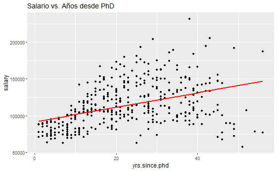

```r
ggplot(df, aes(yrs.since.phd, salary)) +
  geom_point() +
  geom_smooth(method = "lm", se = FALSE, color = "red") +
  labs(title = "Salario vs. Años desde PhD")
```

Aunque se intuye una cierta tendencia que las relaciona, lo cierto es que no es muy fuerte. Es cierto que para valores muy bajos de “años desde el doctorado” los salarios se acumulan por debajo de los 100.000$, pero para valores superiores a 40 años también existen salarios cercanos a 50.000$. Estos puntos en la zona inferior derecha (muchos años desde el doctorado y salarios muy bajos) pueden corresponder con profesores asociados que, a pesar de llevar muchos años en posesión del doctorado, colaboran de manera puntual o a tiempo parcial con la universidad. Por ello, no se considera la variable “yrs.since.phd” una variable muy explicativa del salario.

De hecho, si modificamos la línea de regresión por una curva suave vemos que la relación no es lineal, pero los datos tampoco se ajustan muy bien a dicha curva, por lo que se decarta una fuerte relación entre ambas variables.

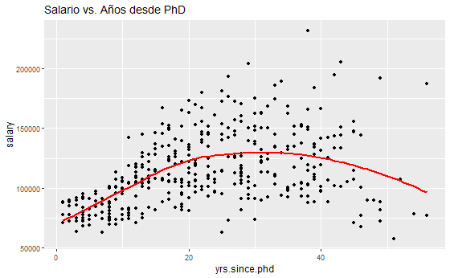

```r
ggplot(df, aes(yrs.since.phd, salary)) +
  geom_point() +
  geom_smooth(method = "loess", se = FALSE, color = "red") +
  labs(title = "Salario vs. Años desde PhD")
```

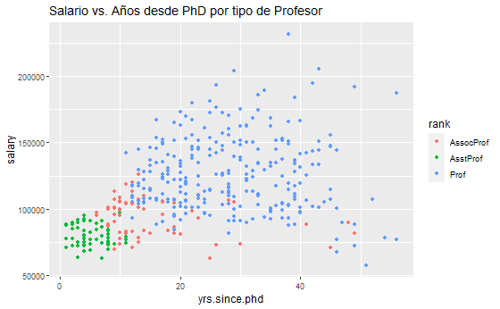

```r
ggplot(df, aes(x = yrs.since.phd, y = salary, color = rank)) +
  geom_point() +
  labs(title = "Salario vs. Años desde PhD por tipo de Profesor")
```

Relación yrs.service - salary:

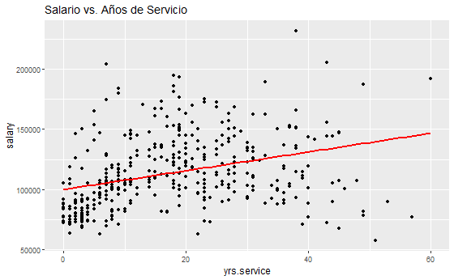

```r
ggplot(df, aes(yrs.service, salary)) +
  geom_point() +
  geom_smooth(method = "lm", se = FALSE, color = "red") +
  labs(title = "Salario vs. Años de Servicio")
```

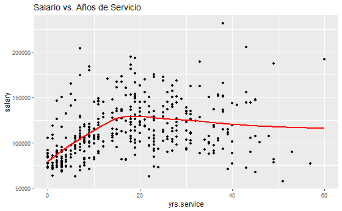

```r
ggplot(df, aes(yrs.service, salary)) +
  geom_point() +
  geom_smooth(method = "loess", se = FALSE, color = "red") +
  labs(title = "Salario vs. Años de Servicio")
```

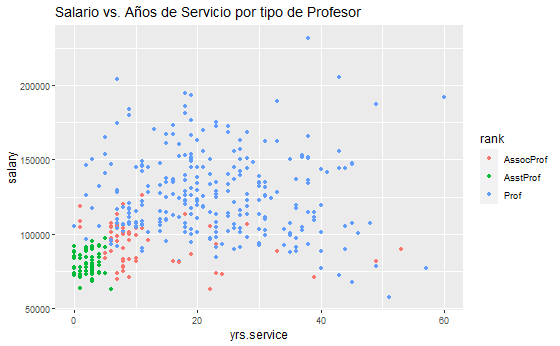

```r
ggplot(df, aes(x = yrs.service, y = salary, color = rank)) +
  geom_point() +
  labs(title = "Salario vs. Años de Servicio por tipo de Profesor")
```

Tras realizar las mismas gráficas que para el estudio de la relación del salario con los años desde el doctorado, se puede comprobar que los años de servicio en la empresa influyen en cierta manera, pero no tanto como se esperaba. La intuición nos decía que la relación lineal sería de cierta fuerza, pero no ha sido así. De hecho, parece que sí es fuerte los primeros años, donde la curva loess comienza con pendiente y prácticamente como una recta de regresión, pero a partir del año 15 aproximadamente, pierde bruscamente la pendiente y se mantiene cuasi horizontal hasta el final del gráfico. Además, se puede observar fácilmente que, a pesar de esta horizontalidad, los datos desde el año 15 hasta el 60 están muy alejados de la curva, por lo que no se ajustan a ésta.

Finalmente, si hacemos la misma gráfica introduciendo el facetting y comprobando los distintos tipos de profesor, vemos una distribución muy similar a la que se ve en la relación salario vs años desde el doctorado por tipo de profesor: los Porfesores Asistentes se acumulan en la zona inferior izquierda, por lo que llevan todos ellos poco tiempo en la organización y cobran salarios muy bajos (ésto podría deberse al hecho de que, al ser asistentes, buscan otras opciones en otras universidades, por lo que no suelen acumular muchos años al salir de la organización cuando son contratados como profesores titulares o asociados, o bien porque terminan sus colaboraciones con la universidad y dejan de acumular años en ella); los Profesores Asociados acumulan algunos años más y mejores salarios, aunque no por mucho, y los Profesores titulares son quienes cobran los salarios más altos con diferencia, independientemente de los años que lleven en la organización. De hecho, se vuelve a dar el caso de profesores titulares con muchos años de trabajo acumulados en la universidad y salarios extremadamente bajos.

Relación sex - salary:

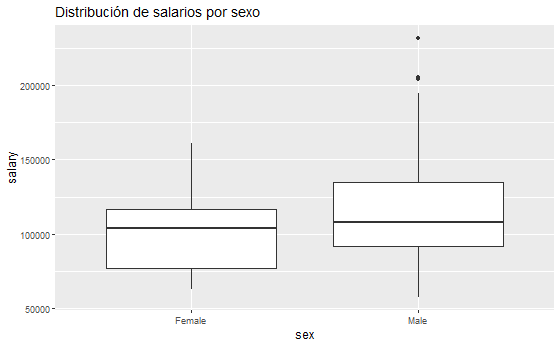

```r
ggplot(df, aes(sex, salary)) +
  geom_boxplot() +
  labs(title = "Distribución de salarios por sexo")
```

En principio, aunque se ve claramente que los hombres cobran más o, mejor dicho, llegan a salarios más elevados (incluidos los puntos outliers que coinciden exactamente con los outliers vistos en el gráfico que estudiaba los tipos de profesor), también es cierto que los salarios más bajos corresponden a los hombres, como muestra el bigote inferior que alcanza valores más bajos. Del mismo modo, las medianas se encuentran en nieveles muy similares, si bien los hombres acumulan mayor concentración en salarios por encima de su mediana y las mujeres por debajo de la suya.

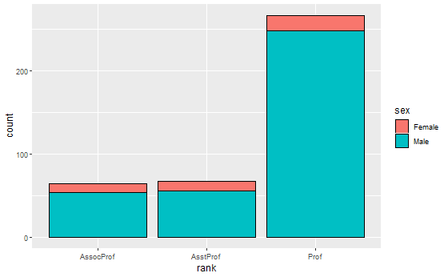

```r
ggplot(df, aes(rank, fill=sex)) +
  geom_histogram(position="stack", stat="count", color="black")
```

Conclusiones:

Mientras algunas de las hipótesis que se barajaban al principio han quedado refrendadas por los gráficos, como que el rango del profesor tiene una gran influencia en el salario y que el sexo por sí mismo no influye en gran medida en éste, también se han encontrado evidencias de que otras hipótesis no se cumplen, como que los años de servicio en la universidad no influyen tanto como se esperaba.

Por otro lado, los valores superiores a 200.000$ de salario son considerados outliers por lo que deberían ser eliminados estas observaciones antes de continuar con cualquier otro análisis que se pretenda realizar.

En conclusión, la variables variables presentan las siguientes influencias sobre los salarios (a tenor de las gráficas y sin haber realizado análisis estadístico): - Rango del profesor: fuerte influencia, siendo los Profesores titulares los que mayores salarios tienen con diferencia, luego los Profesores Asociados y finalmente los Profesores Asistentes. - Disciplina: influencia media-baja, dado que no existen grandes diferencias entre las categorías de esta variable, pues tanto los profesores de A como los de B tienen unos salarios que no distan demasiado unos de otros, si bien los de la categoría B cobran algo más en general. - Años desde el doctorado: influencia baja, no se aprecia en los gráficos que la evolución de los años del doctorado afecten al salario. - Años de servicio: influencia media-baja, durante los 15 primeros años de trabajo en la universidad se aprecia un crecimiento de los salarios, pero desde este punto deja de existir relación alguna, por lo que no se considera que sea una buena variable predictora. - Sexo: influencia baja-nula, si se acepta la premisa de que la diferencia que se aprecia entre los boxplots de hombres y mujeres vienen más dados por el hecho de que los hombres son mucho más numerosos que las mujeres en los puestos de Profesores titulares, que son los que más cobran.

2. ¿Se puede emplear un test paramétrico para determinar si las medias de salarios entre hombres y mujeres son las mismas o difieren? Hay que tener en cuenta que, en tanto que se pide usar un test paramétrico, se deberá determinar si las muestras cumplen con las hipótesis necesarias.

En este caso, se podría emplear un test t de Student aplicado sobre dos muestras para comparar sus medias y determinar si son iguales o, por el contrario, son significativamente distintas. Pero este test requiere del cumplimiento previo de unos requisitos, como son la independencia de las muestras, que ambas se aproximen por una distribución normal y la homogeneidad de sus varianzas.

En primer lugar mostramos la media de ambos sexos:

```r
df_male <- df %>% filter(sex=="Male")
df_female <- df %>% filter(sex=="Female")

mean(df_male$salary)
```

```
[1] 115090.4
```

```r
mean(df_female$salary)
```

```
[1] 101002.4
```

```r
nrow(df_male)
```

```
[1] 358
```

```r
nrow(df_female)
```

```
[1] 39
```

En segundo lugar, respecto a la independencia de las muestras, cabe decir que las muestras provenientes de la misma población, cuando se toman sin reemplazamiento, no son independientes, ya que el hecho de seleccionar un elemento para una muestra condiciona para que ese elemento no se encuentre en la otra muestra y viceversa, por lo que, el hecho de seleccionar hombres por un lado y mujeres por otro, condiciona el hecho de que en una muestra no hayan mujeres y en la otra no hayan hombres. Es decir, no se trata de dos muestras que hayan sido seleccionadas aleatoriamente de la población, sino atendiendo a un rasgo concreto de ésta.

Por este motivo no se considera que las muestras sean independientes. En cualquier caso, y con motivo de realizar la prueba pertinente, se considerará cada grupo como una población diferente, de modo que se procederá a tomar una muestra aleatoria de cada conjunto, de modo que estas submuestras sí se considerarán independientes.

```r
sample_male <- sample_n(df_male, nrow(df_female))
sample_female <- df_female
salary_male <- sample_male$salary
salary_female <- sample_female$salary

nrow(sample_male)
```

```
[1] 39
```

```r
nrow(sample_female)
```

```
[1] 39
```

```r
cor(sample_male$salary, sample_female$salary)
```

```
[1] 0.04080879
```

```r
cor(sample_male$salary, sample_female$salary)^2
```

```
[1] 0.001665358
```

Como se ha dicho, la relación linal entre ambas muestras es muy débil, dado que no son realmente independientes.

Lo siguiente a comprobar es que ambas muestras se aproximan por una normal. Para ello se realizará el test de Shapiro-Wilk y se graficará mediante QQplots para comprobar si siguen distribuciones normales.

Para ambos casos, la H0 será que la muestra proviene de una población con una distribución que se puede aproximar por una normal.

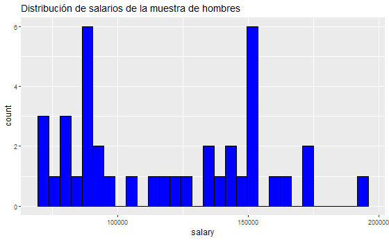

```r
ggplot(sample_male, aes(salary)) +
  geom_histogram(bins = 30, fill = "blue", color = "black") +
  labs(title = "Distribución de salarios de la muestra de hombres")
```

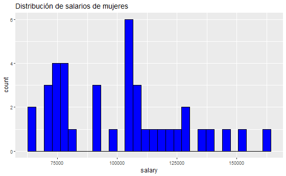

```r
ggplot(sample_female, aes(salary)) +
  geom_histogram(bins = 30, fill = "blue", color = "black") +
  labs(title = "Distribución de salarios de mujeres")
```

```r
shapiro.test(salary_male)
```

```
    Shapiro-Wilk normality test

data:  salary_male
W = 0.91843, p-value = 0.007779
```

```r
shapiro.test(salary_female)
```

```
    Shapiro-Wilk normality test

data:  salary_female
W = 0.94665, p-value = 0.06339
```

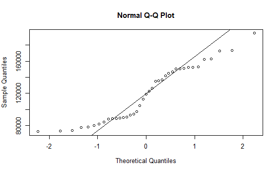

```r
qqnorm(salary_male)
qqline(salary_male)
```

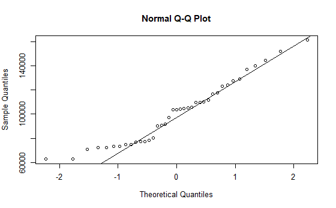

```r
qqnorm(salary_female)
qqline(salary_female)
```

Se puede comprobar tanto gráficamente en la distribución como por el p-valor del test de Shapiro y el QQplot, que los salarios de los hombres no se pueden aproximar por una distribución normal. En cambio, el de las mujeres, que tiene un p-valor algo superior a la significación 0.05 que nos permite no rechazar la H0, se puede considerar que se aproxima a una normal si bien no es una aproximación muy fuerte, como demuestran el gráfico de su distribución y el QQplot asociado.

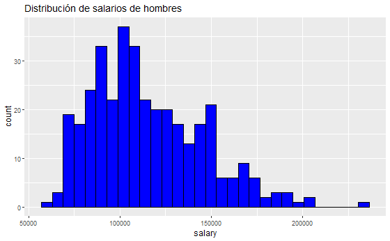

```r
ggplot(df_male, aes(salary)) +
  geom_histogram(bins = 30, fill = "blue", color = "black") +
  labs(title = "Distribución de salarios de hombres")
```

```r
shapiro.test(df_male$salary)
```

```
    Shapiro-Wilk normality test

data:  df_male$salary
W = 0.95877, p-value = 1.735e-08
```

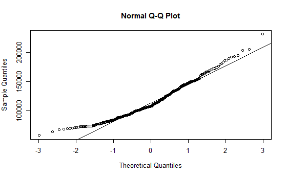

```r
qqnorm(df_male$salary)
qqline(df_male$salary)
```

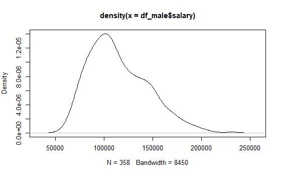

```r
plot(density(df_male$salary))
```

Si aplicamos el test de Shapiro sobre toda la población de hombres, vemos que su p-valor es insignificante, por lo que se rechaza la H0 de que se aproxima a una distribución normal.

```r
shapiro.test(log(salary_male))
```

```
    Shapiro-Wilk normality test

data:  log(salary_male)
W = 0.91904, p-value = 0.008124
```

```r
shapiro.test(sqrt(salary_male))
```

```
    Shapiro-Wilk normality test

data:  sqrt(salary_male)
W = 0.92035, p-value = 0.00892
```

```r
shapiro.test(1/salary_male)
```

```
    Shapiro-Wilk normality test

data:  1/salary_male
W = 0.90823, p-value = 0.003832
```

```r
shapiro.test(salary_male^2)
```

```
    Shapiro-Wilk normality test

data:  salary_male^2
W = 0.90319, p-value = 0.002727
```

```r
shapiro.test(salary_male^3)
```

```
    Shapiro-Wilk normality test

data:  salary_male^3
W = 0.87071, p-value = 0.0003536
```

```r
rango <- max(sample_male$salary) - min(sample_male$salary)
sample_male$salary_t <- (sample_male$salary - min(sample_male$salary))/rango
```

```r
shapiro.test(exp(sample_male$salary_t))
```

```
    Shapiro-Wilk normality test

data:  exp(sample_male$salary_t)
W = 0.9054, p-value = 0.003163
```

Aplicando el test de Shapiro sobre distintas transformaciones de la muestra de salarios de hombres, no siguen dando todas ellas valores insignificantes para el p-valor, por lo que ninguna de ellas se aproxima por una distribución normal.

Finalmente, hay que comprobar la homogeneidad de las varianzas mediante una prueba F para igualdad de varianzas. Esta prueba es extremadamente sensible a la hipótesis de normalidad, y, como hemos determinado que la muestra de hombres no se distribuye como una normal, la prueba F no será válida.

En conclusión, las muestras no son independientes y la de los hombres no se puede aproximar por una distribución normal, lo que hace que se incumplan los dos primeros requisitos para poder aplicar el test t de Student y, además, al no poder aproximar por una distribución normal la muestra de los hombres no es posible estudiar la homogeneidad de las varianzas mediante una prueba F, lo que hace que tampoco se cumpla el tercer requisito. Por todo ello, se puede concluir que no es posible realizar un test paramétrico para determinar si las medias de salarios entre hombres y mujeres son las mismas o difieren, ya que no se cumplen las hipótesis necesarias.

3. Dividir el dataset tomando las primeras 317 instancias como train y las últimas 80 como test. Entrenar un modelo de regresión lineal con regularización Ridge y Lasso en train seleccionando el que mejor MSE tenga. Dar las métricas en test. Valorar el uso del one hot encoder, y, en caso de emplearlo, argumentarlo.

Dividimos los datos en dos nuevos dataframe:

```r
df_train <- df[0:317,]
df_test <- df[318:397,]
```

```r
df_train
```

|  | rank | discipline | yrs.since.phd | yrs.service | sex | salary |
| --- | --- | --- | --- | --- | --- | --- |
| 1 | Prof | B | 19 | 18 | Male | 139750 |
| 2 | Prof | B | 20 | 16 | Male | 173200 |
| 3 | AsstProf | B | 4 | 3 | Male | 79750 |
| 4 | Prof | B | 45 | 39 | Male | 115000 |
| 5 | Prof | B | 40 | 41 | Male | 141500 |
| 6 | AssocProf | B | 6 | 6 | Male | 97000 |
| 7 | Prof | B | 30 | 23 | Male | 175000 |
| 8 | Prof | B | 45 | 45 | Male | 147765 |
| 9 | Prof | B | 21 | 20 | Male | 119250 |
| 10 | Prof | B | 18 | 18 | Female | 129000 |

[output cut: 307 more lines]

```r
df_test
```

|  | rank | discipline | yrs.since.phd | yrs.service | sex | salary |
| --- | --- | --- | --- | --- | --- | --- |
| 318 | Prof | B | 46 | 45 | Male | 67559 |
| 319 | Prof | B | 16 | 16 | Male | 134550 |
| 320 | Prof | B | 16 | 15 | Male | 135027 |
| 321 | Prof | B | 24 | 23 | Male | 104428 |
| 322 | AssocProf | B | 9 | 9 | Male | 95642 |
| 323 | AssocProf | B | 13 | 11 | Male | 126431 |
| 324 | Prof | B | 24 | 15 | Female | 161101 |
| 325 | Prof | B | 30 | 31 | Male | 162221 |
| 326 | AsstProf | B | 8 | 4 | Male | 84500 |
| 327 | Prof | B | 23 | 15 | Male | 124714 |

[output cut: 70 more lines]

Antes de comenzar, y dado que las variables rank, discipline y sex han sido transformadas en categóricas, está justificado el uso del one hot encoder para transformarlas en variables binarias que indiquen la presencia o no de cada una de las categorías en la observación. De esta manera, facilitaremos la ejecución del modelo ya que las entradas deben ser numéricas, y empleando el one hot encoder en lugar del label encoder, evitamos interpretaciones erróneas que pueden ocurrir si consideramos una categoría como 1 y otra como 2, pues, si por ejemplo transformamos “Male” en 1 y “Female” en 2, estaríamos diciendo al modelo que las observaciones con “Female” o 2 tienen un valor el doble que “Male” o 1, cosa que no es cierta.

```r
df_train_encoded <- df_train[sapply(df_train, is.numeric)]
df_train_encoded$prof <- ifelse(df_train$rank == "Prof", 1, 0)
df_train_encoded$assoc.prof <- ifelse(df_train$rank == "AssocProf", 1, 0)
df_train_encoded$asst.prof <- ifelse(df_train$rank == "AsstProf", 1, 0)
df_train_encoded$disc.a <- ifelse(df_train$discipline == "A", 1, 0)
df_train_encoded$disc.b <- ifelse(df_train$discipline == "B", 1, 0)
df_train_encoded$male <- ifelse(df_train$sex == "Male", 1, 0)
df_train_encoded$female <- ifelse(df_train$sex == "Female", 1, 0)

df_train_encoded
```

|  | yrs.since.phd | yrs.service | salary | prof | assoc.prof | asst.prof | disc.a | disc.b | male | female |
| --- | --- | --- | --- | --- | --- | --- | --- | --- | --- | --- |
| 1 | 19 | 18 | 139750 | 1 | 0 | 0 | 0 | 1 | 1 | 0 |
| 2 | 20 | 16 | 173200 | 1 | 0 | 0 | 0 | 1 | 1 | 0 |
| 3 | 4 | 3 | 79750 | 0 | 0 | 1 | 0 | 1 | 1 | 0 |
| 4 | 45 | 39 | 115000 | 1 | 0 | 0 | 0 | 1 | 1 | 0 |
| 5 | 40 | 41 | 141500 | 1 | 0 | 0 | 0 | 1 | 1 | 0 |
| 6 | 6 | 6 | 97000 | 0 | 1 | 0 | 0 | 1 | 1 | 0 |
| 7 | 30 | 23 | 175000 | 1 | 0 | 0 | 0 | 1 | 1 | 0 |
| 8 | 45 | 45 | 147765 | 1 | 0 | 0 | 0 | 1 | 1 | 0 |
| 9 | 21 | 20 | 119250 | 1 | 0 | 0 | 0 | 1 | 1 | 0 |
| 10 | 18 | 18 | 129000 | 1 | 0 | 0 | 0 | 1 | 0 | 1 |

[output cut: 307 more lines]

```r
df_test_encoded <- df_test[sapply(df_test, is.numeric)]
df_test_encoded$prof <- ifelse(df_test$rank == "Prof", 1, 0)
df_test_encoded$assoc.prof <- ifelse(df_test$rank == "AssocProf", 1, 0)
df_test_encoded$asst.prof <- ifelse(df_test$rank == "AsstProf", 1, 0)
df_test_encoded$disc.a <- ifelse(df_test$discipline == "A", 1, 0)
df_test_encoded$disc.b <- ifelse(df_test$discipline == "B", 1, 0)
df_test_encoded$male <- ifelse(df_test$sex == "Male", 1, 0)
df_test_encoded$female <- ifelse(df_test$sex == "Female", 1, 0)

df_test_encoded
```

|  | yrs.since.phd | yrs.service | salary | prof | assoc.prof | asst.prof | disc.a | disc.b | male | female |
| --- | --- | --- | --- | --- | --- | --- | --- | --- | --- | --- |
| 318 | 46 | 45 | 67559 | 1 | 0 | 0 | 0 | 1 | 1 | 0 |
| 319 | 16 | 16 | 134550 | 1 | 0 | 0 | 0 | 1 | 1 | 0 |
| 320 | 16 | 15 | 135027 | 1 | 0 | 0 | 0 | 1 | 1 | 0 |
| 321 | 24 | 23 | 104428 | 1 | 0 | 0 | 0 | 1 | 1 | 0 |
| 322 | 9 | 9 | 95642 | 0 | 1 | 0 | 0 | 1 | 1 | 0 |
| 323 | 13 | 11 | 126431 | 0 | 1 | 0 | 0 | 1 | 1 | 0 |
| 324 | 24 | 15 | 161101 | 1 | 0 | 0 | 0 | 1 | 0 | 1 |
| 325 | 30 | 31 | 162221 | 1 | 0 | 0 | 0 | 1 | 1 | 0 |
| 326 | 8 | 4 | 84500 | 0 | 0 | 1 | 0 | 1 | 1 | 0 |
| 327 | 23 | 15 | 124714 | 1 | 0 | 0 | 0 | 1 | 1 | 0 |

[output cut: 70 more lines]

Se comenzará entrenando el modelo de regresión lineal conregularización de Ridge con MSE:

```r
library(glmnet)
```

```r
X_train <- data.matrix(subset(df_train_encoded, select = - salary))
Y_train <- df_train_encoded$salary

mod_ridge <- cv.glmnet(X_train, Y_train, family="gaussian", alpha=0, type.measure="mse")
best_lambda_ridge <- mod_ridge$lambda.min
best_lambda_ridge
```

```
[1] 1865.816
```

El valor óptimo de lambda es 1865.816 según el modelo de Ridge, mientras el valor del error cuadrático para este valor lambda mínimo dado en MSE sería:

```r
min(mod_ridge$cvm)
```

```
[1] 486931066
```

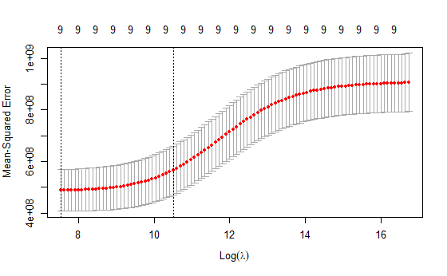

```r
plot(mod_ridge)
```

Los coeficientes para cada variable son los siguientes según el lambda óptimo:

```r
coef(mod_ridge, s=best_lambda_ridge)
```

```
10 x 1 sparse Matrix of class "dgCMatrix"
                       s1
(Intercept)   100442.6212
yrs.since.phd    377.7293
yrs.service     -420.6139
prof           21783.9735
assoc.prof    -10553.6767
asst.prof     -23041.8769
disc.a         -7407.2786
disc.b          7378.0378
male            1983.6049
female         -1992.0047
```

A continuación, se aplicará un modelo de Lasso:

```r
mod_lasso <- cv.glmnet(X_train, Y_train, family="gaussian", alpha=1, type.measure="mse")
best_lambda_lasso <- mod_lasso$lambda.min
best_lambda_lasso
```

```
[1] 27.70678
```

El valor óptimo de lambda es 27.70678 según el modelo de Lasso, mientras el valor del error cuadrático para este valor lambda mínimo dado en MSE sería:

```r
min(mod_lasso$cvm)
```

[output not shown]

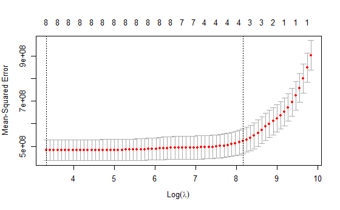

```r
plot(mod_lasso)
```

Los coeficientes para cada variable según el lambda óptimo son:

```r
coef(mod_lasso, s=best_lambda_lasso)
```

```
10 x 1 sparse Matrix of class "dgCMatrix"
                         s1
(Intercept)    9.487018e+04
yrs.since.phd  5.908437e+02
yrs.service   -6.618744e+02
prof           3.322400e+04
assoc.prof     .
asst.prof     -1.321854e+04
disc.a        -1.544977e+04
disc.b         4.925076e-09
male           3.690206e+03
female        -4.924397e-09
```

Se puede apreciar que la variable assoc.prof, que corresponde a la variable booleana para determinar si es profesor asociado o no, ha sido eliminada en este método.

```r
X_test <- data.matrix(subset(df_test_encoded, select = - salary))
Y_test <- df_test_encoded$salary

pred_ridge <- predict.glmnet(mod_ridge$glmnet.fit, newx = X_test, s=best_lambda_ridge)
pred_lasso <- predict.glmnet(mod_lasso$glmnet.fit, newx = X_test, s=best_lambda_lasso)
```

Al realizar las predicciones, comprobaremos el porcentaje de acierto de cada modelo:

```r
predicciones <- data.frame(Y_test)
predicciones$pred_ridge <- c(pred_ridge)
predicciones$pred_lasso <- c(pred_lasso)
predicciones$resid_ridge <- predicciones$Y_test-predicciones$pred_ridge
predicciones$resid_lasso <- predicciones$Y_test-predicciones$pred_lasso
predicciones$dif_ridge <- (predicciones$resid_ridge/Y_test)*100
predicciones$dif_lasso <- (predicciones$resid_lasso/Y_test)*100

predicciones
```

| Y_test | pred_ridge | pred_lasso | resid_ridge | resid_lasso | dif_ridge | dif_lasso |
| --- | --- | --- | --- | --- | --- | --- |
| 67559 | 130036.16 | 129178.85 | -62477.1621 | -61619.850 | -92.4779262 | -91.208943 |
| 134550 | 130902.08 | 130647.90 | 3647.9154 | 3902.105 | 2.7111969 | 2.900115 |
| 135027 | 131322.70 | 131309.77 | 3704.3015 | 3717.230 | 2.7433784 | 2.752953 |
| 104428 | 130979.62 | 130741.52 | -26551.6221 | -26313.524 | -25.4257691 | -25.197767 |
| 95642 | 98864.63 | 97921.11 | -3222.6262 | -2279.114 | -3.3694676 | -2.382963 |
| 126431 | 99534.32 | 98960.74 | 26896.6842 | 27470.260 | 21.2738048 | 21.727472 |
| 161101 | 130368.92 | 132346.31 | 30732.0763 | 28754.686 | 19.0762791 | 17.848856 |
| 162221 | 129881.09 | 128991.59 | 32339.9129 | 33229.408 | 19.9357130 | 20.484036 |
| 84500 | 88101.77 | 87421.10 | -3601.7661 | -2921.098 | -4.2624451 | -3.456921 |
| 124714 | 133966.80 | 135445.68 | -9252.8038 | -10731.676 | -7.4192182 | -8.605029 |

[output cut: 70 more lines]

```r
ridge_mse <- mean((Y_test - pred_ridge)^2)
lasso_mse <- mean((Y_test - pred_lasso)^2)

ridge_mse
```

```
[1] 629394807
```

```r
lasso_mse
```

```
[1] 642528706
```

A tenor de los resultados, ambos modelos son bastante poco precisos: llegan a cometer errores de más del 90% en alguna predicción (aunque se podría tratar de alguno de los outliers que se vieron al principio, pues no se llegaron a eliminar). En todo caso, el error cuadrático medio del modelo de Ridge es inferior al del modelo de Lasso, por lo que debería ser seleccionado como modelo a emplear.

4. Estudiar la normalidad de los residuos del modelo resultante. ¿Se detecta algún sesgo?

Como ya tenemos los residuos del modelo de Ridge para la muestra de test calculados, los rescatamos y trabajaremos con ellos. Vamos a realizar las mismas pruebas para ellos que realizamos anteriormente para comprobar la normalidad de las muestras de hombres y mujeres: un test de Shapiro-Wilk donde la H0 será que la muestra se puede aproximar por una normal, y unos gráficos QQplot para comprobarlo visualmente.

```r
residuos <- predicciones$resid_ridge

shapiro.test(residuos)
```

```
    Shapiro-Wilk normality test

data:  residuos
W = 0.95896, p-value = 0.01162
```

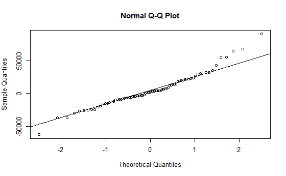

```r
qqnorm(residuos)
qqline(residuos)
```

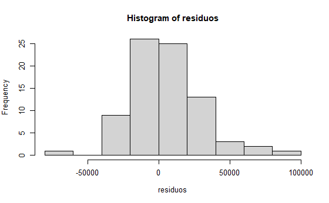

```r
hist(residuos)
```

En primer lugar, según el test de Shapiro-Wilk, tenemos un p-valor inferior al nivel de significación 0.05, por lo que se rechaza la H0 de que los residuos siguen una distribución normal, si bien es cierto que el valor de W es muy cercano a 0.95, la gráfica QQplot nos muestra cierta cercanía a la línea teórica y el histograma de distribución de los residuos nos presenta una forma similar a la de una distribución normal. En conclusión, dado el p-valor de la prueba de Shapiro-Wilk, los residuos no siguen una distribución normal, pero dados el resto de elementos, podemos afirmar que se distribuye de manera relativamente cercana a una distribución normal.

Respecto del sesgo, en el histograma podemos ver que los residuos se encuentran relativamente centrados en torno a 0, aunque se aprecia un leve sesgo hacia la derecha.

5. ¿Qué conclusiones se extraen de este estudio y del modelo implementado? ¿Es correcto el rendimiento de este?

Las conclusiones finales son las siguientes: - La mayoría de variables del estudio no son variables predictoras adecuadas, a excepción del rango del profesor, que sí parece una variable que discrimina bien el salario de cada observación. - Los tests paramétricos para el estudio de las medias de las muestras de hombres y mujeres no pueden ser aplicados dado que una de éstas no se aproxima por una normal y, además, no se consideran muestras independientes. - Ninguno de los modelos lineales, ni el de regularización de Ridge ni el de Lasso, son especialmente precisos, si bien el de Ridge muestra un MSE un tanto inferior, por lo que se lo considera “mejor”. - Los residuos, aunque se aproximan, no se distribuyen según una normal y tienen un pequeño sesgo a la derecha.

Como consecuencia de todo ésto, no considero el modelo implementado como un modelo eficiente y su rendimiento no es óptimo, por lo que lo descartaría y trataría de buscar otras alternativas, como, por ejemplo, un método stepwise que eliminara aquellas variables no predictoras, o buscar alternativas a la regresión lineal.